# Stats 810 Fall 2015, class 12. Internet repositories for collaboration and open-source research: git and github

Edward Ionides

12/3/2015

Licensed under the Creative Commons attribution-noncommercial license, http://creativecommons.org/licenses/by-nc/3.0/. Please share and remix noncommercially, mentioning its origin.

## Objectives

- As discussed in class, git is currently the dominant tool for managing, developing and sharing code within the computational sciences and industry. Github is the largest git-based internet repository, but others (such as bitbucket) also use git, and it can be useful to use git to build a local repository on your own computer.
- Our goals are
  1. Learn some ways to think about what a git repository is and how it works.
  2. Practice going through the process of downloading a github repository, editing it, and uploading the changes.
- This introduction uses material from Karl Broman’s practical and minimal git/github tutorial ([kbroman.org/github_tutorial](http://kbroman.org/github_tutorial/)). A deeper, more technical tutorial is [www.atlassian.com/git/tutorials](https://www.atlassian.com/git/tutorials/).
- Git was developed for Unix-like systems (Linux and Mac). According to [Wikpedia’s article on git](https://en.wikipedia.org/wiki/Git_%28software%29)

“The Microsoft Windows ‘port’ of Git is primarily a Linux emulation framework that hosts the Linux version. […] Currently there is no native port of Git for Windows.”

- If your laptop runs Windows, your time is probably better spent figuring out how to do this assignment on a Linux or Mac machine belonging to the department or a friend. That is, unless you really want to restrict yourself to Windows.

## Getting started with git and github

1. Get an account on github.
2. If you are on a Mac or Linux machine, git will likely be installed already. Otherwise, you can download and install it from git-scm.com/downloads.
3. Set up your local git installation with your user name and email. Open a terminal and type:

```
$ git config --global user.name "Your name here"
$ git config --global user.email "your_email@example.com"
```

(Don’t type the $; that just indicates that you’re doing this at the command line.)

4. Optional but recommended: set up secure password-less SSH communication to github, following the [github instructions](https://help.github.com/articles/generating-ssh-keys/). If you run into difficulties, it may help to look at [Roger Peng’s SSH help page](http://www.biostat.jhsph.edu/bit/nopassword.html).

## Basic git concepts

- **repository**. A representation of the current state of a collection of files, and its entire history of modifications.
- **commit**. A commit is a change to one or many of the files in repository. The repository therefore consists of a directed graph of all previous commits.
- **branch**. Multiple versions of the collection of files can exist simultaneously in the repository. These versions are called branches. Branches may represent new functionality, or a bug fix, or different versions of the code with slightly different goals.
  - Branches have names. A special name called **master** is reserved for the main development branch.
  - Branches can be **created**, **deleted** or **merged**.
  - Each new commit is assigned to a branch.
- We now have the pieces in place to visualize the **graph** of a git repository. [Picture credit: [hades.github.io](http://hades.github.io/media/git/git-history.png)]

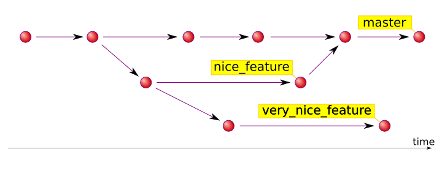

- Take some time to identify the commits, branching events, and merging events on the graph.
  - Note that branch names actually are names for the most recent commit on that branch, known as the **head** of the branch.

## An elementary task: cloning a remote repository

- In a suitable directory, type

```
git clone git@github.com:ionides/810f15
```

- You now have a local copy of the Stats 810 class materials.
- The local repository remembers the address of the remote repository it was cloned from.
  - You can pull any changes from the remote repository to your local repository using **git pull**.

```
[ionides@feller 810f15]$ git pull
Already up-to-date.
```

## A workflow to contribute to the 810f15 github repository

- If you tell me your github username, I could in principle add you as a developer of the `ionides/810f15` github repository. Then you can commit changes directly.
- However, here, let’s practice something a bit more fancy. We will follow a standard workflow for proposing a change to someone else’s github repository.

### Forking a project and making a pull request

**Forking** is making your own github copy of a repository. A **pull request** is a way to ask the owner of the repository to pull your changes back into their version. The following steps guide you through a test example.

1. Go to `ionides/810f15` on github, for example by searching for `810f15`.
2. Click `fork` at the top right-hand corner, and follow instructions to add a forked copy to your own github account. It should now show up in your account as `my_username/810f15`.
3. Clone a local copy of the forked repository to your machine, e.g.,

```
git clone git@github.com:my_username/810f15
```

4. Move to the `810f15` directory and edit the file `sign_here.html` to add your own name.
5. It can be helpful to type

```
git status
```

regularly to check on the current state of the repository.

5. Commit this change to your local version of the forked `810f15`,

```
git add sign_here.html
git commit -m "sign up for my_name"
```

and see how the `git status` has changed. Another useful command for checking on the recent action in the repository is

```
git log
```

6. Push this change to the forked `810f15` on github:

```
git push
```

7. On the github web site for the `my_username/810f15` fork, click `New pull request` and follow instructions. When you have successfully placed your pull request, the owner of the forked repository (me) will be notifed. I will then pull the modifications from your fork into `ionides/810f15`.